# Problem Set 2 (CSS)

**1.4** Calculate Burt’s constraint measure for each node. Interpret the distribution. *(1 Points)*

```r
constraint_g1 <- na.omit(constraint(graph1, weights = NULL))

summary(constraint_g1)
```

```
   Min. 1st Qu.  Median    Mean 3rd Qu.    Max.
 0.1951  0.3160  0.4410  0.5033  0.5785  1.3889
```

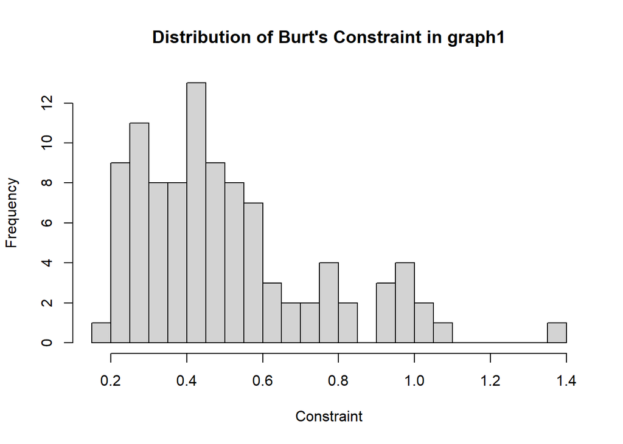

```r
hist(
  constraint_g1,
  breaks = 30,
  main = "Distribution of Burt's Constraint in graph1",
  xlab = "Constraint"
)
```

A high constraint value means that an actor’s contacts are closely connected to one another, so the actor has little access to non-redundant information. A low constraint value indicates more brokerage potential: the actor is connected to contacts who are not all connected among themselves. In `graph1`, the distribution is skewed, with many actors having relatively low constraint and some actors being much more embedded in closed local neighborhoods.

**1.5** Why does Burt propose the constraint measure instead of traditional centrality measures? *(1 Points)*

Burt’s constraint measure captures whether an actor’s contacts are redundant or non-redundant. Traditional centrality measures such as degree or betweenness mainly describe how central a node is, but they do not directly show whether the actor bridges structural holes and therefore has access to diverse information and brokerage opportunities.

**2 Analyze `graph3` with respect to segregation and cohesion**

**2.1** Calculate segregation based on gender and pocket money. Interpret the results. *(2 Points)*

```r
assortativity_nominal(
  graph3,
  types = as.factor(V(graph3)$gender),
  directed = FALSE
)
```

```
[1] 0.783343
```

```r
assortativity(
  graph = graph3,
  values = V(graph3)$money,
  directed = FALSE
)
```

```
[1] -0.04376366
```

**2.2** Create subnetworks for boys and girls. Which one is more cohesive? *(1 Point)*

```r
#Male
induced_subgraph(graph3, V(graph3)[gender == 0]) |>
  transitivity(type = "global")
```

```
[1] 0.4976303
```

```r
#Female
induced_subgraph(graph3, V(graph3)[gender == 1]) |>
  transitivity(type = "global")
```

```
[1] 0.5124224
```

Females are more clustered.

**2.3** Which group is more cohesive: smokers or non-smokers? What can we make of this? *(1 Point)*

```r
# Non-smokers: smoking == 1, smokers: smoking > 1
non_smokers_g3 <- induced_subgraph(graph3, V(graph3)[smoking == 1])
smokers_g3 <- induced_subgraph(graph3, V(graph3)[smoking > 1])

transitivity(non_smokers_g3, type = "global")
```

```
[1] 0.4147465
```

```r
transitivity(smokers_g3, type = "global")
```

```
[1] 0.3846154
```

The non-smokers group with the higher global transitivity is more cohesive.

**2.4** Create a random network of the same size. Compare density, dyad census, and clustering. Reflect: Is this comparison helpful? *(2 Points)*

```r
set.seed(1)

rand <- erdos.renyi.game(vcount(graph3),
                         ecount(graph3),
                         type = "gnm",
                         directed = FALSE
                         )
metrics <- data.frame(
  Measure = c("Transitivity", "Edge Density", "Dyad Mutual",  "Dyad Null"),
  Original = c(
    transitivity(graph3, type = "global"),
    edge_density(graph3),
    dyad_census(graph3)$mut,
    #dyad_census(graph3)$asym,
    dyad_census(graph3)$null
  ),
  Random = c(
    transitivity(rand, type = "global"),
    edge_density(rand),
    dyad_census(rand)$mut,
    #dyad_census(rand)$asym,
    dyad_census(rand)$null
  )
)
metrics
```

```
       Measure     Original       Random
1 Transitivity 4.717557e-01 2.627737e-02
2 Edge Density 3.610949e-02 3.610949e-02
3  Dyad Mutual 1.860000e+02 1.860000e+02
4    Dyad Null 4.965000e+03 4.965000e+03
```

Not very. As density is always influenced by the number of edges and nodes, it is not surprising that the random graph has the same density as the original graph. The dyad census also shows that the number of mutual and null dyads is similar, which is expected given the same number of edges. The transitivity (clustering) is much higher in the original graph than in the random graph, which suggests that there is a significant amount of clustering in the original network that is not due to chance. However, this comparison does not tell us much about the specific social processes at play in the original network, and it does not account for other factors such as homophily or social influence that may be driving the observed patterns.

**3** Colin Cluster is a teacher at the respective school in Glasgow. Over time he observes the following:

1. The “cool kids” are more likely to smoke weed than others.
2. The older the students get, the more likely they are to smoke weed.
3. Over time, weed smokers seem to form tighter friend groups, than non weed smokers.

However, he’s not quite sure how to verify these observations using appropriate measures. Can you help him?

**3.1** Choose a measure to identify *cool kids*. Justify your choice. *(2 Points)*

A suitable measure is degree centrality or eigenvector centrality. Degree centrality identifies students with many friendship ties, while eigenvector centrality gives higher scores to students who are connected to other well-connected students. Both measures count if justified!

**3.2** Are the *cool kids* more likely to smoke weed at time $t1$? *(1 Point)*

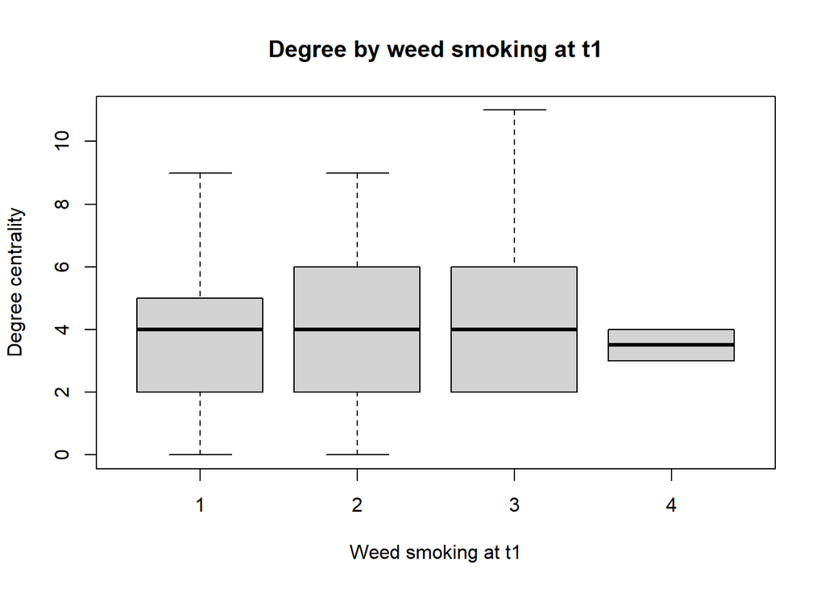

```r
V(graph1)$degree <- degree(graph1, mode = "all")
V(graph1)$eigen <- eigen_centrality(graph1, weights = E(graph1)$weight)$vector

df_t1 <- data.frame(
  weed = factor(V(graph1)$weed),
  degree = V(graph1)$degree,
  eigen = V(graph1)$eigen
)

boxplot(degree ~ weed, data = df_t1,
        xlab = "Weed smoking at t1",
        ylab = "Degree centrality",
        main = "Degree by weed smoking at t1")
```

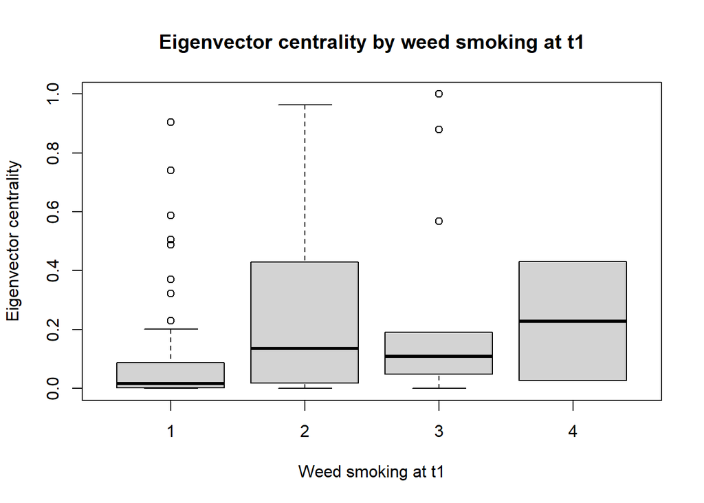

```r
boxplot(eigen ~ weed, data = df_t1,
        xlab = "Weed smoking at t1",
        ylab = "Eigenvector centrality",
        main = "Eigenvector centrality by weed smoking at t1")
```

```r
aggregate(cbind(degree, eigen) ~ weed, data = df_t1, mean)
```

```
  weed   degree      eigen
1    1 3.838235 0.08957153
2    2 4.500000 0.27876228
3    3 4.642857 0.24288953
4    4 3.500000 0.22896849
```

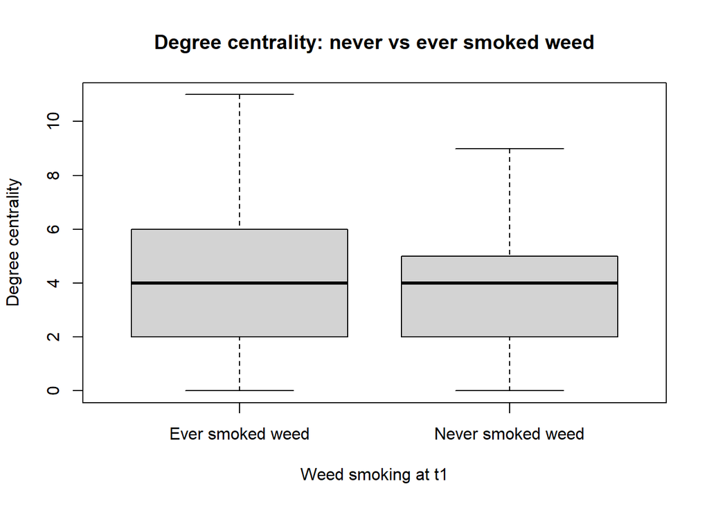

```r
df_t1_binary <- data.frame(
  weed_binary = factor(
    ifelse(is.na(V(graph1)$weed), NA,
           ifelse(V(graph1)$weed == 1,
                  "Never smoked weed",
                  "Ever smoked weed"))
  ),
  degree = V(graph1)$degree,
  eigen = V(graph1)$eigen
)


boxplot(degree ~ weed_binary, data = df_t1_binary,
        xlab = "Weed smoking at t1",
        ylab = "Degree centrality",
        main = "Degree centrality: never vs ever smoked weed")
```

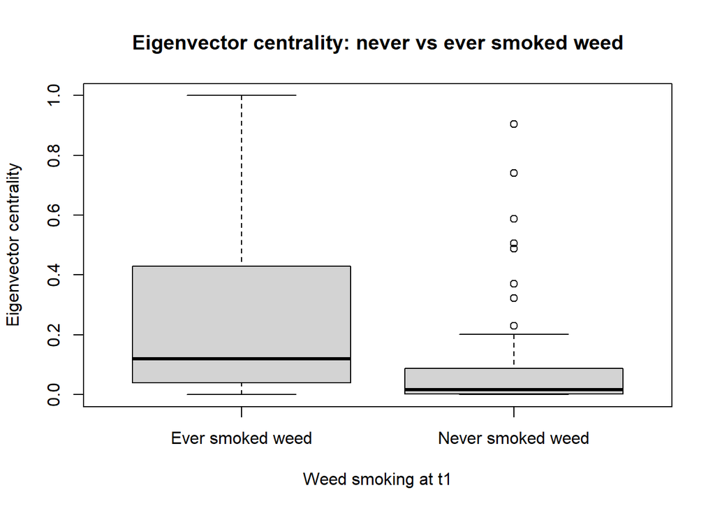

```r
boxplot(eigen ~ weed_binary, data = df_t1_binary,
        xlab = "Weed smoking at t1",
        ylab = "Eigenvector centrality",
        main = "Eigenvector centrality: never vs ever smoked weed")
```

**3.3** Plot the network at time $t1$, showing information on the relationship strength, the weed smoking behvior of the persons, gender and their ‘coolness factor’. *(2 Points)*

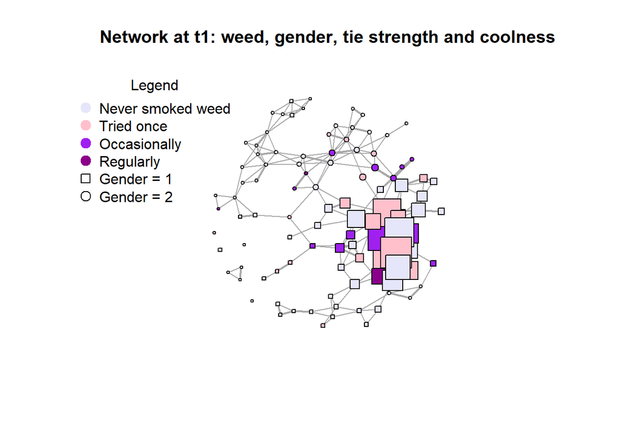

```r
# Coolness factor: eigenvector centrality
V(graph1)$eigen <- eigen_centrality(graph1, weights = E(graph1)$weight)$vector

# Node color by weed smoking behavior
V(graph1)$color <- ifelse(
  V(graph1)$weed == 1, "lavender",
  ifelse(V(graph1)$weed == 2, "pink",
         ifelse(V(graph1)$weed == 3, "purple", "darkmagenta"))
)

# Node shape by gender
V(graph1)$shape <- ifelse(V(graph1)$gender == 1, "square", "circle")

# Edge width by relationship strength
E(graph1)$width <- E(graph1)$weight * 2

set.seed(1)
layout1 <- layout_with_fr(graph1)

plot(
  graph1,
  layout = layout1,
  vertex.size = V(graph1)$eigen * 25 + 3,
  vertex.label = NA,
  vertex.color = V(graph1)$color,
  vertex.shape = V(graph1)$shape,
  edge.width = E(graph1)$width,
  edge.arrow.size = 0,
  main = "Network at t1: weed, gender, tie strength and coolness"
)


legend(
  "topleft",
  legend = c(
    "Never smoked weed",
    "Tried once",
    "Occasionally",
    "Regularly",
    "Gender = 1",
    "Gender = 2"
  ),
  col = c("lavender", "pink", "purple", "darkmagenta", "black", "black"),
  pch = c(21, 21, 21, 21, 22, 21),
  pt.bg = c("lavender", "pink", "purple", "darkmagenta", "white", "white"),
  pt.cex = 1.5,
  bty = "n",
  title = "Legend"
)
```

**3.4** Plot networks for $t1$, $t2$ and $t3$. From the visual analysis,does smoking weed lead to stronger clustering over time? *(2 Points)*

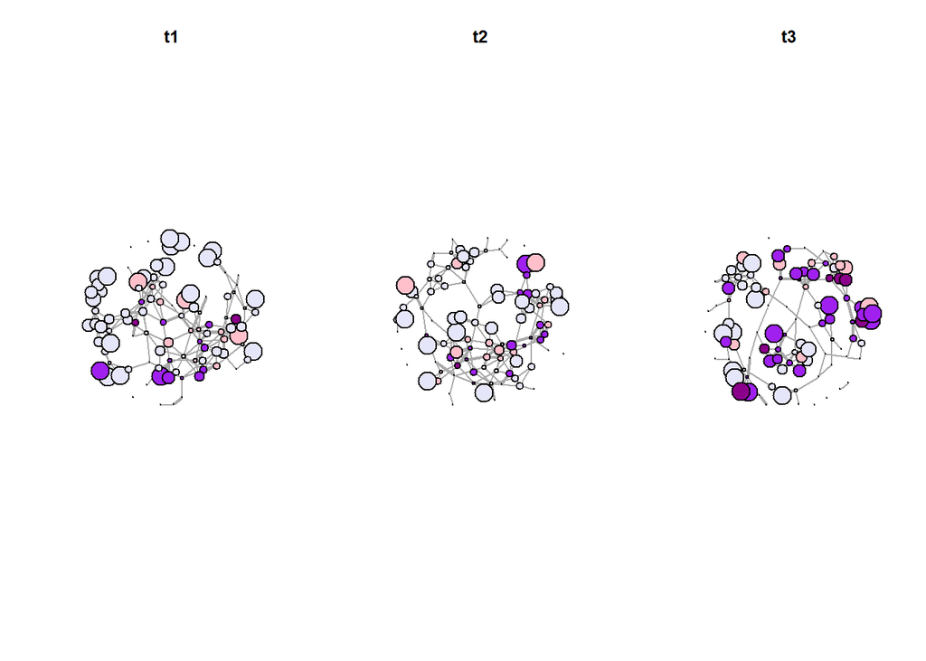

```r
plot_weed_network <- function(g, title) {
  plot(
    g,
    layout = layout_with_fr(g),
    vertex.size = transitivity(g, type = "local", isolates = "zero") * 20 + 2,
    vertex.label = NA,
    vertex.shape = "circle",
    vertex.color = ifelse(
      V(g)$weed == 1, "lavender",
      ifelse(V(g)$weed == 2, "pink",
             ifelse(V(g)$weed == 3, "purple", "darkmagenta"))
    ),
    edge.width = E(g)$weight * 2,
    main = title
  )
}

par(mfrow = c(1, 3))
plot_weed_network(graph1, "t1")
plot_weed_network(graph2, "t2")
plot_weed_network(graph3, "t3")
```

```r
par(mfrow = c(1, 1))
```

From the plots alone, we should be cautious: visual clustering can suggest whether weed smokers increasingly appear in tighter groups, but it does not prove that weed smoking leads to stronger clustering. A stronger answer would compare clustering coefficients for weed smokers and non-weed smokers across all three waves and then use a longitudinal model to separate selection from influence.